# Kalman Filter lab

Sina Brar and Athinthtra Krishnaswamy

22:55 27 September 2015

## Nile’s annual flow

```r
library("FKF")
library("dlm")
```

The `Nile` data set is built into R (it’s in the `datasets` recommended package) - it doesn’t need to be loaded explicitly.

## Lab Activity

Read through the following code, to see an example of Kalman filtering using the `dlm` package.

Afterwards, try doing this example using the `FKF` package. Read through the `FKF` documentation either [online](https://cran.r-project.org/web/packages/FKF/FKF.pdf) or via `help(package="FKF")`.

Then, use either the `dlm` or `FKF` package to do Kalman filtering on the nhtemp or JohnsonJohnson datasets in R, using the same model.

Commands to install packages:

```r
install.packages("FKF")
install.packages("dlm")
```

## dlm: Dynamic Linear Model

### dlm package example using Nile Flow data

An object of class `dlm` is created through the dlm function:

```r
dlm(m0, C0, FF, V, GG, W)
```

where

- `V`: covariance matrix of observation equation
- `FF`: transition matrix of observation equation
- `W`: covariance matrix of state equation
- `GG`: transition matrix of state equation (i.e., prediction
- `m0`, `C0`: initial values of mean and variance-covariance matrix

The `dlmModReg`, `dlmModPoly`, `dlmModARMA`, and `dlmModSeas` functions create particular objects of class `"dlm"`; see the documentation for further details

For this example, we have the following model:

```
x[t]  = GG * x[t-1] + w[t]
z[t]  = FF * x(t) + v(t)
```

with `FF == GG == 1`. `W` is the covariance of `w[t]` the process noise; `V` is the covariance of `v[t]`, the observation noise.

- **Q**: what kind of dynamics are we assuming with this model???
1. We need to find values for `GG`, `FF`, `V`, `W`, `m0`, `C0` in order to apply KF
2. `FF` and `GG` are already known, `m0` and `C0` receive default values
3. We’ll use maximum likelihood estimation to find values for `W` and `V`

### Finding the MLE of W and V

Note: `dlm` has a specific function in the package for this. Since FKF only has two functions, one can use optim to do essentially the same thing. The function `optim` optimizes is the loglikelihood which is one of the values returned by the `fkf` function. See the FKF documentation for more details or command `?fkf` in the shell

`dlm` uses the function `dlmMLE`:

```r
 dlmMLE(y, parm, build,...)
```

where

- `y`: data
- `parm`: initial values for parameters that need to be estimated
- `build`: function that takes a vector of the same length as `parm`, and returns object of class `dlm` It returns the MLE of unknown parameters in the specification of a state space model. The unknown parameters in this case are `V` and `W`

`dlmMLE` takes a function that returns a `dlm` object as one of its arguments. It then gives us the estimates of the unknown parameters in the model specified by that `dlm` object. So we need a function that will create our `dlm` object/model:

`nileBuild` creates a dlm with FF = 1, GG = 1, m0 = 0, C0=1e+07, and variance matrices as specified by `par`, a vector of length 2.

```r
nileBuild <- function(par) {
    dlmModPoly(1, dV = exp(par[1]), dW = exp(par[2]))
}
```

`dlmModPoly` creates an nth order `dlm` model. The default values it takes are as follows:

```r
dlmModPoly(order=2, dV = 1, dW = c(rep(0, order - 1), 1),
       m0 = rep(0, order), C0 = 1e+07 * diag(nrow = order))
```

It returns an object of class `dlm` You could also use the `dlm()` function and specify the known values for the arguments.

Call `dlmMLE`:

```r
nileMLE <- dlmMLE(Nile, rep(0,2), nileBuild)
nileMLE$par #vector containing estimates of V and W
```

```
## [1] 9.622437 7.291951
```

Now use the MLEs found in above step to create a `dlm` object (model)

```r
(nileMod <- nileBuild(nileMLE$par))
```

```
## $FF
##      [,1]
## [1,]    1
##
## $V
##         [,1]
## [1,] 15099.8
##
## $GG
##      [,1]
## [1,]    1
##
## $W
##          [,1]
## [1,] 1468.432
##
## $m0
## [1] 0
##
## $C0
##       [,1]
## [1,] 1e+07
```

Apply the Kalman Filter to our model: `dlmFilter(y, mod)` with data `y` and a `mod` object of class `dlm` applies Kalman filter to compute filtered values of the state vectors, together with their variance/covariance matrices.

```r
nileFilt <- dlmFilter(Nile, nileMod)
```

call `?dlmFilter` to see what it returns

Plot the flow data together with filtered values of the state vectors:

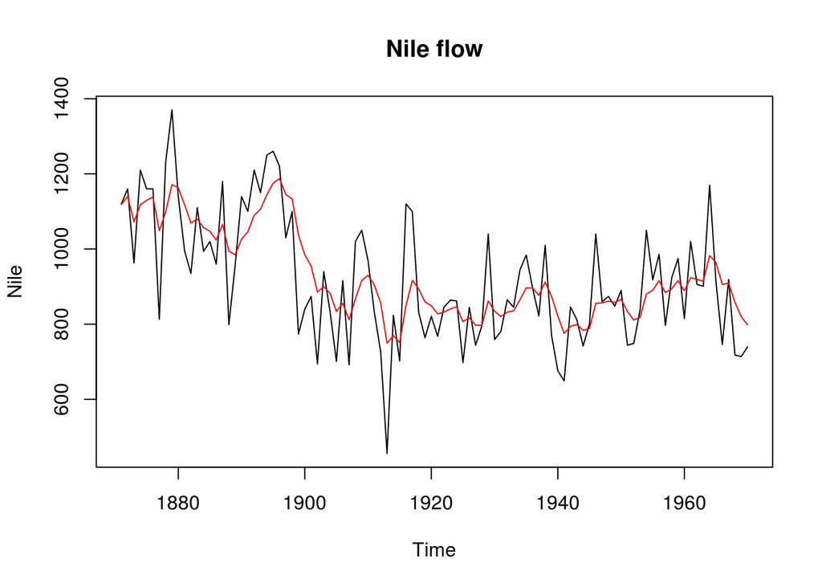

```r
plot(Nile, main = "Nile flow")
tvec <- c(time(Nile))  ## extract time vector, drop time-series attributes
lines(x=tvec,y=nileFilt$m[-1], col = "red")
```